# A scalar problem illustrating stiffness

[AMath 586, Spring Quarter 2019](http://staff.washington.edu/rjl/classes/am586s2019/) at the University of Washington. For other notebooks, see Index.html or the [Index of all notebooks on Github](https://github.com/rjleveque/amath586s2019/blob/master/notebooks/Index.html).

This notebook shows the solution to the ODE

$$ u'(t) = \lambda(u(t)-\cos(t)) - \sin(t), \qquad u(t_0) = \eta $$

as $t_0, \eta,$ and $\lambda$ are varied. This ODE is used in Examples 7.1 and 8.1 of [the textbook](http://staff.washington.edu/rjl/fdmbook/).

The exact solution is

$$ u(t) = \cos(t) + \exp(\lambda(t-t_0))(\eta - \cos(t_0)). $$

Note in particular that if $u(0)=1$ is specified then the solution is just $u(t)=\cos(t)$ and if $\lambda=0$ then other solutions remain parallel to this, since in this case the ODE $u'(t)=-\sin(t)$ has solution $u(t) = \cos(t) + (\eta - \cos(t_0))$. Note that in this case $f(u,t)$ is independent of $u$ and the ODE can be solved by simple integration.

If $\lambda<0$ then solutions decay towards this "slow solution". This equation exhibits *stiffness* when $\lambda$ is very negative and we wish to compute the solution for over times that are long relative to $-1/\lambda$.

```python
%matplotlib inline
```

```python
from pylab import *
from ipywidgets import interact, IntSlider, FloatSlider
```

```python
tfinal = 6*pi
def utrue(t0, eta, lam):
    t = linspace(t0,tfinal,1000)
    u = cos(t) + exp(lam*(t-t0))*(eta - cos(t0))
    return t,u
```

```python
def plot_soln(t0, eta, lam):
    t,u = utrue(t0, eta, lam)
    figure(figsize=(10,4))
    axis([0,tfinal, -3,3])
    tequil = linspace(0, tfinal, 1000)
    plot(tequil, cos(tequil), 'k', label='solution with $u(0)=1$')
    plot([t[0]], [u[0]], 'ro', label='initial data')
    plot(t, u, 'r', label='solution with specified data')
    legend(loc='upper right')
    grid(True)
    title('With $\lambda = %.1f,$' % lam)
```

Here's a typical solution, when $u(3) = 2$ is specified as initial data, with $\lambda=-2$:

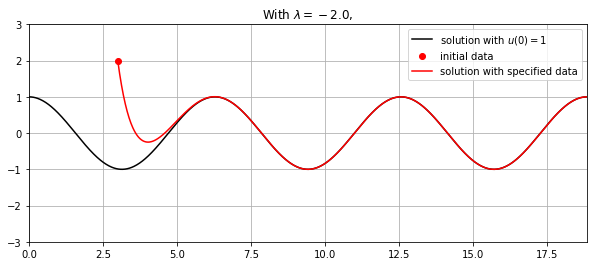

```python
plot_soln(3, 2, -2)
```

The interact below allows you to vary the parameters. Note that changing $\eta$ with $\lambda=0$ gives solution curves that are "parallel" to the slow solution, and that decreasing $\lambda$ gives decay towards this solution.

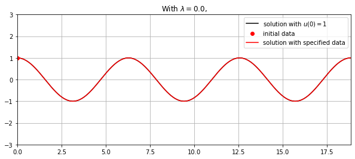

```python
interact(plot_soln, t0=IntSlider(min=0,max=10,value=0, description='$t_0$'),
         eta=FloatSlider(min=-2.5,max=2.5,step=0.5,value=1., description='$\eta$'),
         lam=FloatSlider(min=-20,max=0,step=0.5,value=0,description='$\lambda$'));
```